# Практикум

© Alexander Doynikov,dep. CS, MSU

Febriary 19, 2024

# Проверка статистических гипотез

Гипотезой называется любое утверждение о виде, свойствах наблюдаемых случайных величин. Правило, согласно которому проверяемая гипотеза принимается или отвергается называется критерием. Гипотезы, проверямые на практике, можно условно поделить на следующие типы:

1. Гипотеза о виде распределения.
2. Гипотеза однородности.
3. Гипотеза независимости.
4. Гипотеза случайности.
5. Гипотеза о параметрах распределения

Приведем пример для каждой из перечисленных выше типов гипотез.

## Гипотеза о виде распределения.

Пусть производится n независимых наблюдений над некоторой случайной величиной с неизвестной функцией распределения $F_{\xi}(x)$ В качестве основной гипотезы $H_0$ примем предположение, что

$$H_0 : F_{\xi} (x) =F(x)$$
где функция распределения $F(x)$ полностью известна. Либо

$$H_0:F_{\xi}(x)\in Ϝ$$

где $Ϝ$ - заданное семейство распределений, которое может быть задано параметрически

$$F={F(x,\theta),\theta\in\Theta}$$

## Гипотеза однородности.

Пусть проведено $k$ серий независимых наблюдений по $n$ наблюдений в каждой. Результатами которых будут наборы

$$x_{i_1},....x_{i_{n}},\mspace{25mu}
i=1,...,k$$

В качестве основной гипотезы $H_0$ рассмотрим предположение, что закон распределения не изменится при переходе от одной серии к другой. Другими словами, если $F_{i}(x)$- вообще говоря, неизвестная функция распределения наблюдений $i$-ой серии, то

$$H_0:F_1(x)≡...≡F_{k}(x)$$

## Гипотеза независимости.

Пусть в случайном эксперименте наблюдается двухмерная случайная величина с неизвестной функцией распределения $F_{\xi}(x,y)$. Под гипотезами независимости будем понимать гипотезы вида.

$$H_0:F_{\xi}(x,y)=F_{\xi_1}(x)F_{\xi_2}(x)$$

где $F_{\xi_{i}}(x)$-функции распределения одномерных случаных величин $\xi_{i}\mspace{25mu} i=1,2$.

## Гипотеза случайности.

Пусть результаты эксперимента есть $n$-мерная случайная величина $X=(x_1,...,x_{n})$ с неизвестной функцией распределения $F_{X}(x)=F(x_1,...,x_{n}).$ Предположение о том, X является выборкой из независимых наблюдений над некоторой случайной величиной $\xi$ называют гипотезой случайности

$$H_0:F_{X}(x)=F_{\xi}(x_1)∙...∙F_{\xi}(x_{n})$$

Другими словами гипотезой случайности называют предположение о том, что компоненты выборки независимы и одинаково распределены.

## Критерии согласия

Общим методом построения критериев является следующая процедура. Пусть о распределении некоторой случайной величины $X=(x_1,...,x_{n})$ сформулирована гипотеза. Для того, чтобы построить критерий надо попытаться найти такую статистику $T(X)$, которая характеризует отклонение эмпирических данных от результатов, соответсвующих гипотез. Более того, распределение статистики $T(X)$ при этом известно точно или приближенно. Предположим, что такая статистика найдена. Пусть $T:{t:t=T(x),x\in X}$ множество всех значений статистики $T$. Для произвольного фиксированного $\epsilon>0$ определим множество $T_{\epsilon}⊂T$ такое, что
$$P [T(x)\in
T_{\epsilon}|H_0]<\epsilon$$

Тогда правило проверки гипотезы $H_0$ можно сформулировать следующим образом: Пусть $x$ - наблюдавшаяся реализация случайной величины $X$ и $t=T(x)$ соответсвующее значение статистики $Т$.

Если $t\in T_{\epsilon}$ то, при предположениях основной гипотезы произошло маловероятное событие и гипотеза $H_0$ отвергается. В противном случае говорят, что нет оснований отвергать гипотезу $H_0$.

Статистику $T(x)$ называют статистикой критерия.

множество $T_{\epsilon}$ - критическое множество.

Если при этом также сформулирована и альтернативная гипотеза $H_1$, то $P[T(x)\in T_{\epsilon}|H_1]$ - мощностью критерия

**В дальнейшем в курсе всегда будем считать (если это не будет особо оговорено), что уровень значимости равен 0.05**.

## Гипотеза однородности

### Критерий Уилкоксона.

Метод был разработан в 1945 году американским статистиком и химиком Фрэнком Уилкоксоном.

Пусть имеется две выборки $X=(x_1,...,x_{n})$ и $Y=(y_1,...y_{m})$. В качестве основной гипотезы выдвинем предположение об идентичности их функций распределения

$$F_{X}(x)=F_{Y}(y)$$

Назовем рангом $R(i,k)$ - порядковый номер элемента в обобщенной упорядоченной выборке размера $k=n+m$ Пусть $s=\Sigma_{i=1}^nR(i,k)$.

Тогда при предположении, что гипотеза $H_0$ действительно имеет место

$$s\sim N(n(k+1),((mnk)/2))$$
Смоделируем две одинаково распределенные выборки. Тест Уилкоксона не должен отвергнуть гипотезу одинаковой распределенности.

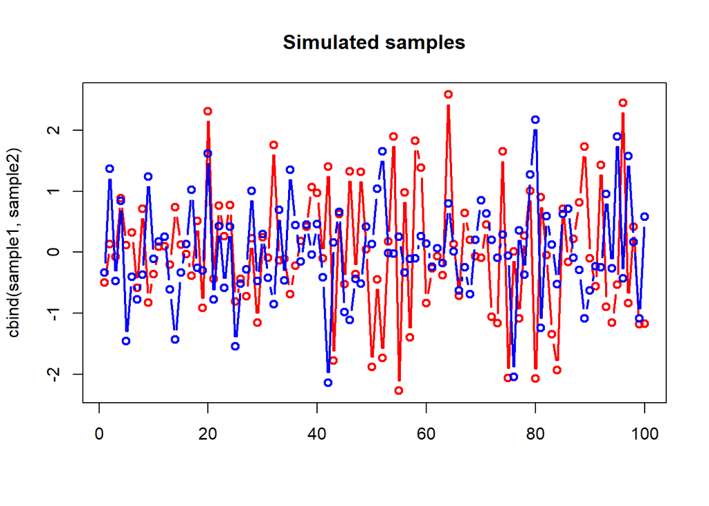

```r
set.seed(100)
sample1<- rnorm(100,mean = 0,sd = 1)
sample2<- rnorm(100,mean = 0,sd = 1)
matplot(cbind(sample1,sample2), type ="b",main = "Simulated samples",pch = 21,col = c('red','blue'),lty = 1,lwd = 2)
```

```r
wilcox.test(sample1, sample2, paired = T)
```

```
##
##  Wilcoxon signed rank test with continuity correction
##
## data:  sample1 and sample2
## V = 2567, p-value = 0.8865
## alternative hypothesis: true location shift is not equal to 0
```

P-value больше нашего заданного уровня значимости 0.05. Вывод:гипотеза об однородности не отвергается. Чтобы показать случай, когда гипотеза однородности отвергается смоделируем еще одну выборку с заведомо другим распределением

```r
sample3<- rnorm(100,mean = 2,sd = 4)
wilcox.test(sample1, sample3, paired = T)
```

```
##
##  Wilcoxon signed rank test with continuity correction
##
## data:  sample1 and sample3
## V = 1229, p-value = 8.415e-06
## alternative hypothesis: true location shift is not equal to 0
```

P-value меньше нашего заданного уровня значимости 0.05. Вывод:гипотеза об однородности отвергается.

### Критерий Смирнова.

Пусть $F_{1n}(x)$ и $F_{2n}(x)$ - эмпирические функции распределения первой и второй выборки соответственно.

Рассмотрим статистику
$$D_{nm}=sup_{x}|F_{1n}(x)-F_{2n}(x)|$$

По теореме Смирнова (1944) при предположении справедливости гипотезы $H_0$ и $n,m->\infty$ распределение статистики $\sqrt{\frac{m+n}{nm}}D_{nm}$ стремится к распределению Колмогорова
$$K(t)=
\Sigma_{j=-\infty}^{\infty}(-1)^{j}exp(-2j^2t^2)$$

Пусть
$$t_{\alpha}=\sqrt{\frac{n+m}{nm}}\lambda_{\alpha}$$
где $K(\lambda_{\alpha})=1-\alpha$

Тогда гипотезу однородности отвергают, если значение статистики $t>\sqrt{\frac{n+m}{nm}}\lambda_{\alpha}$

Поcмотрим работу критерия на предыдущих выборках.

```r
ks.test(sample1, sample2)
```

```
##
##  Two-sample Kolmogorov-Smirnov test
##
## data:  sample1 and sample2
## D = 0.11, p-value = 0.5806
## alternative hypothesis: two-sided
```

```r
ks.test(sample1, sample3)
```

```
##
##  Two-sample Kolmogorov-Smirnov test
##
## data:  sample1 and sample3
## D = 0.51, p-value = 1.012e-11
## alternative hypothesis: two-sided
```

Глядя на p-value, делаем вывод:

- в первом случае гипотеза не отвергается,
- во втором случае гипотеза отвергается.

## Гипотеза случайности.

### Медианный тест

Пусть имеется выборка $X=(x_1,...,x_{n})$

По выборке найдем выборочную медиану $x_{m}$. Пометим каждое из наблюдений $+$ или $-$ по следующему правилу:

```
$$x_{i}^+ > x_{m}$$
$$x_{i}^- < x_{m}$$
```

назовем серией последовательность идущих подряд наблюдений со знаком $+$ или $-$. Обозначим через $\nu$ - общее количество серий в ряде. Оказывается, что при предположении справедливости гипотезы случайности, тогда в независимости от распределения случайной величины $\xi$, участвующей в формулировке гипотезы случайности справедливо следующее утверждение

```
$$\nu\sim N(((n+1)/2),n-(1/2))$$
```

Проверка гипотез случайности в R собраны в библиотеку `library(randtest)`. Для демонстрации проверки гипотез случайности подготовим выборку заведомо зависимых случайных величин $X=(x_1,...,x_{n})$. Зависимость будет иметь такой вид
$$x_{t+1}= \phi
x_t+\epsilon_t$$
где $\epsilon_t$ последовательность независимых одинаково предположим нормально распределенных величин с нулевым мат. ожиданием и стандартным отколнением $\sigma$. Забегая вперед почти на семестр ,скажем, что это называется процессом типа AR(1) или Марковским процессом. В качестве $\epsilon_t$ возьмем выборку `sample1` из нее процесс $x_t$.

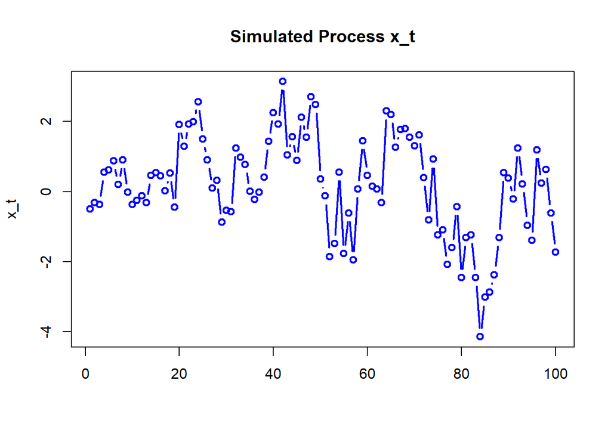

```r
  n   <- 100
  x_t <- rep(0,n)
  fi <- 0.9
  x_t[1]<- sample1[1]
  for (i in 2:n)
  {
    x_t[i]<- fi*x_t[i-1]+sample1[i]
  }
  matplot(x_t, type ="b",main = "Simulated Process x_t",pch = 21,col =
  'blue',lty = 1,lwd = 2)
```

Теперь применим ранговый тест Mann-Kendall на случайность для выборки $\epsilon_t$ это у нас переменная `sample1` и $x_t$ и сравним результаты.

```r
library(randtests)
rank.test(sample1)
```

```
##
##  Mann-Kendall Rank Test
##
## data:  sample1
## statistic = -0.8577, n = 100, p-value = 0.3911
## alternative hypothesis: trend
```

```r
rank.test(x_t)
```

```
##
##  Mann-Kendall Rank Test
##
## data:  x_t
## statistic = -2.3944, n = 100, p-value = 0.01665
## alternative hypothesis: trend
```

Величины p_value позволяют сделать вывод, что для выборки из переменной `sample1` гипотеза случайности не отвергается, а для $x_t$ гипотеза случайности отвергается.

В библиотеке `library(randtests)` собраны несколько разных непараметрических тестов на случайность. У каждого из них есть своя область применимости, где тест работает лучшим образом. Но если этих свойств каждого метода не знаете. То совет простой - применяйте как можно больше разных тестов, и принимайте решения на основе голосования.

```r
rank.test(x_t)
```

```
##
##  Mann-Kendall Rank Test
##
## data:  x_t
## statistic = -2.3944, n = 100, p-value = 0.01665
## alternative hypothesis: trend
```

```r
bartels.rank.test(x_t)
```

```
##
##  Bartels Ratio Test
##
## data:  x_t
## statistic = -6.7903, n = 100, p-value = 1.119e-11
## alternative hypothesis: nonrandomness
```

```r
cox.stuart.test(x_t)
```

```
##
##  Cox Stuart test
##
## data:  x_t
## statistic = 14, n = 50, p-value = 0.002602
## alternative hypothesis: non randomness
```

```r
runs.test(x_t)
```

```
##
##  Runs Test
##
## data:  x_t
## statistic = -3.6183, runs = 33, n1 = 50, n2 = 50, n = 100, p-value =
## 0.0002965
## alternative hypothesis: nonrandomness
```

```r
turning.point.test(x_t)
```

```
##
##  Turning Point Test
##
## data:  x_t
## statistic = -1.5159, n = 100, p-value = 0.1295
## alternative hypothesis: non randomness
```

## Гипотеза независимости

### Критерий χ^2.Таблицы сопряженности

Рассмотрим выборку$(x_1,y_1),...,(x_{n},y_{n})$ из двумерного распределения $F_{\xi}(x,y)$.

Требуется проверить гипотезу независимости

$$H_0:F_{\xi}(x,y)=F_{\xi_1}(x)F_{\xi_2}(x)$$

Множество значений принимаемое сл.величиной $\xi_1$ разбивается на $s$ непересекающихся интервалов $E_1^1,...,E_{s}^1$, а множество значений второй случайной величины на $k$ интервалов $E_1^2,...,E_{k}^2$. Обозначим через $\nu_{ij}$ число одновременных попаданий нашей выборки в $E_{i}^1$ и $E_{j}^2$

$$\Sigma_{i=1}^{s}\Sigma_{j=1}^{k}\nu_{ij}=n$$

Данные эксперимента удобно расположить в виде таблицы, которую называют **таблицей сопряженности**.

$$\begin{equation*}\left[
\begin{matrix}\nu_{1,1}&\nu_{1,2}&...&\nu_{1,k}&\nu_{1.}
\\
\nu_{2,1}&\nu_{2,2}&...&\nu_{2,k}&\nu_{2.}\\.&.&...&.\\\nu_{s,1}&...&.&\nu_{s,k}&\nu_{s.}
\\ \nu_{.1}&\nu_{.2}&.&\nu{.k}&n \end{matrix}
\right]\end{equation*}$$

где $\nu_{i.}=\Sigma_{j=1}^k\nu_{ij}$, $\nu_{.j}=\Sigma_{i=1}^s\nu_{ij}$

Рассмотрим статистику

$$\chi_n^2=\Sigma_{i=1}^{s}\Sigma_{j=1}^{k}\frac{(\nu_{ij}-\nu_{i⋅}\nu_{⋅j})^2}{(\nu_{i⋅}\nu_{⋅j}}$$

Распределение ее стремится при $n->\infty$ к $\chi^2(s-1)(k-1)$.

Этот критерий чаще всего применяют не к числовым, а категориальным.

Например мы хотим проверить гипотезу о независимости цвета глаз и цвета волос. Занумеруем цвет глаз:`blue`,`grey`,`dark` как `1`,`2`,`3`.

А цвет волос:`light`,`Rusyi`,`black`,`brown` как `1`,`2`,`3`,`4`.

Считываем данные

```r
dat <- read.table("eyehair.csv",header = TRUE,sep = ",")
head(dat)
```

```
##   ï..eye hair
## 1      1    1
## 2      1    1
## 3      1    1
## 4      1    1
## 5      1    1
## 6      1    1
```

Данные необходимо представить в виде таблицы сопряженности. Может и есть метод в R, который делает это. Но я решил его не искать, а сделал самостоятельно.

```r
eye <- as.factor(dat[,1])
hair<- as.factor(dat[,2])
M <- matrix(NA,nrow = 3,ncol =4)
rownames(M) <- c("blue","grey","dark")
colnames(M) <- c("light","Rusyi","black","brown")
for (i in 1:3)
for(j in 1:4)
M[i,j] <- length(which((eye == i) & (hair == j)))
M
```

```
##      light Rusyi black brown
## blue    26    10     3     2
## grey    14    18    11     4
## dark     2     6     3     1
```

Остается вызвать критерий.

```r
chisq.test(M)
```

```
##
##  Pearson's Chi-squared test
##
## data:  M
## X-squared = 14.546, df = 6, p-value = 0.0241
```

P-Value=0.0241 гипотезу о независимости следует отвергнуть.

Для числовых данных для проверки независимости является ранговый критерий Спирмана или критерий Кендала.

## Критерий Кендала.

Пусть $(x_1, y_1), (x_2, y_2), …, (x_n, y_n)$ множество пар наблюдений над одновременнй реализацией двух случайных величин $X$ и $Y$ таких, что каждая пара значений уникальна. Про две произвольные пары наблюдений $(x_i, y_y)$ и $(x_j, y_j)$ таких, что $i<j$ будем говорить, что они согласованы(конкордантными), если $x_i>x_j$ и $y_i>y_j$ или $x_i<x_j$ и $y_i<y_j$. В противном случае пары несогласованы (дискордантными).

Пусть
$$\tau
=\frac{[Число-согласованных-пар] -
[Число-несогласованных-пар]}{n(n-1)/2}$$
Свойства

1. Знаменатель это общее комбинаций пар, поэтому

$$−1 \le \tau \le 1$$
.

2.Ecли $X$ и $Y$ независимы то $\tau$ стремится к нулю

Явное выражение для $\tau$

$$\tau = \frac{2}{n(n-1)}\Sigma\Sigma_{i,j
: i<j}(sign(x_i-x_j)sign(y_i-y_j)$$
При предположении независимости $X$ и $Y$ распределение статистики $\tau$ приблизительно нормальное с нулевым среднем и дисперсией
$$\frac{2(2n+5)}{9n(n-1)}$$

Читаем данные курс рубля и одновременные с ним цены на нефть

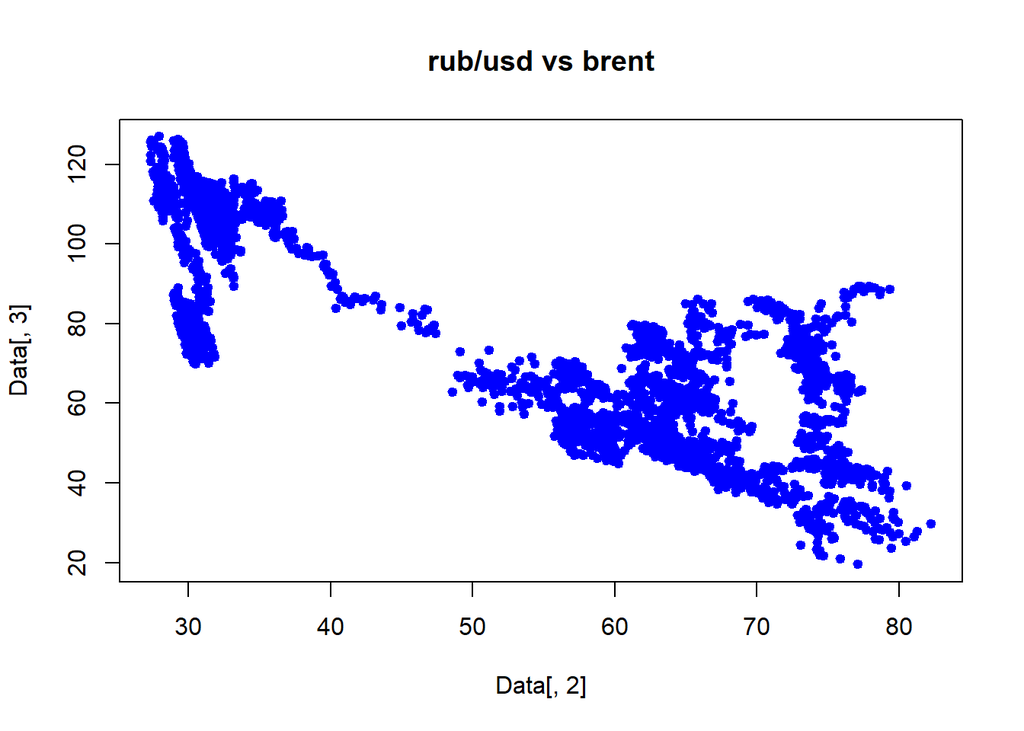

```r
Data <- read.csv("RubleBrent.csv",sep=",")
dt<-  Data[,2]
plot(Data[,2],Data[,3] ,type="p",pch = 20,col = "blue",main = "rub/usd vs brent",lwd=2)
```

Проверяем гипотезу независимости

```r
cor.test(Data[,2],Data[,3], method = "kendall")
```

```
##
##  Kendall's rank correlation tau
##
## data:  Data[, 2] and Data[, 3]
## z = -48.118, p-value < 2.2e-16
## alternative hypothesis: true tau is not equal to 0
## sample estimates:
##        tau
## -0.5313836
```

Гипотеза о независимости курса рубля от цен на нефть очевидно отвергается.

## Гипотеза о распределении

Демонстрацию гипотез о распределении будем проводить на такой выборке. Cмоделируем выборку с заведомо известным нормальным распределением и продемонстрируем проверку гипотез о распределении. Моделируем нормально распределенную выборку с мат.ожиданием $\mu = 3$ и стандартным отклонением $\sigma = 2$.

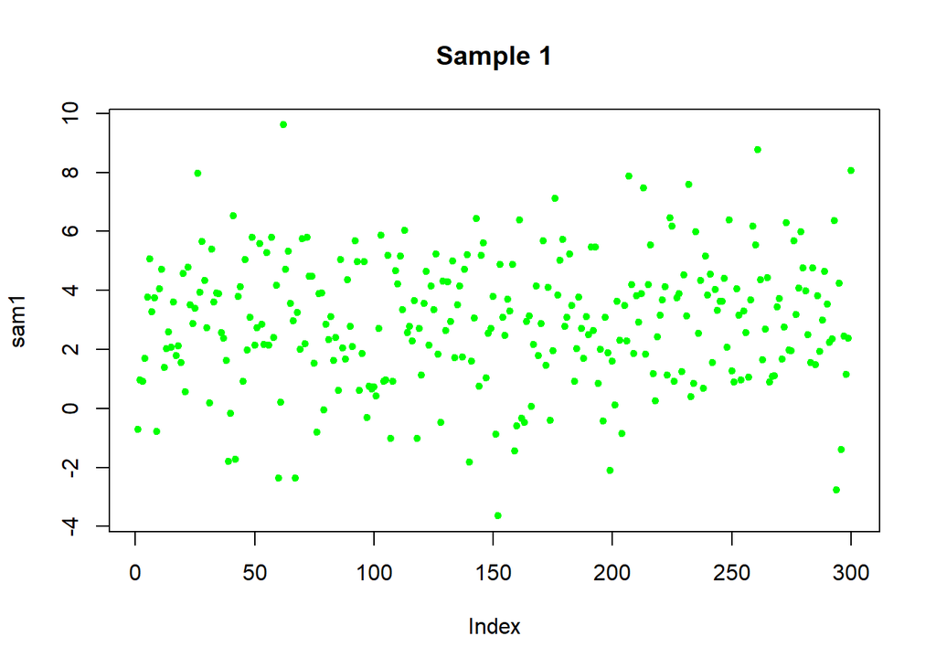

```r
#Distributions in the stats package

n<-300
mu <- 3
sigma<- 2

sam1 <- rnorm(n,mu,sigma)
plot(sam1,type = 'p',pch = 20,col = "green",main = "Sample 1")
```

Построим гистограмму

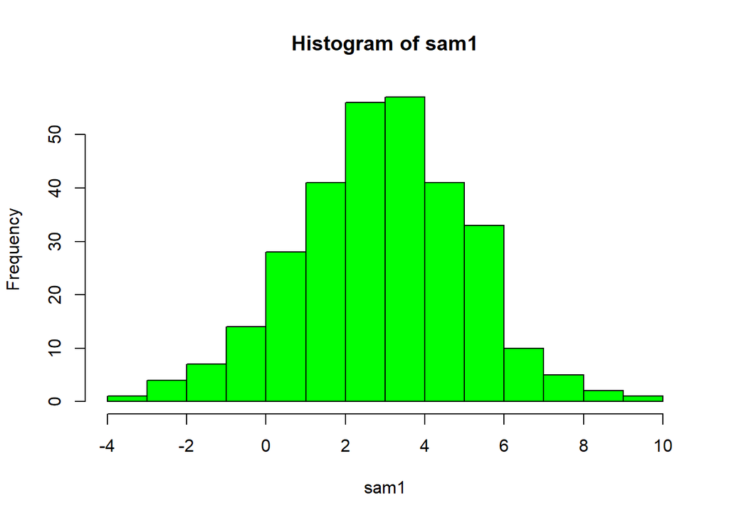

```r
  hist(sam1,col = 'green',lwd = 1)
```

### Критерий Колмогорова-Смирнова

Пусть $F(x)$ - некоторая непрерывная функция распределения (**это главное ограничение применимости критерия**) и $x=(x_1,...,x_{n})$ - выборка построенная из наблюдений над некоторой случайной величиной $\xi$ c неизвестной функцией распределения $F_{\xi}(x)$. Проверим гипотезу

$$H_0:F_{\xi}(x)=F(x)$$

Пусть $F_{n}(x)$-эмпирическая функция распределения, построенная по выборке. Рассмотрим статистику

$$D_{n}=sup_{x}|F_{n}(x)-F(x)|$$

особенностью статистики $D_{n}$ является тот факт, что ее распределение не зависит от $F(x)$

Другое замечательное свойство статистики $D_{n}$ (теорема Колмогорова) состоит в том, что при достаточно больших $n(n>=20)$

$$lim_{n->\infty}P[\sqrt{nD_{n}}<t]=K(t)=\Sigma_{j=-\infty}^{\infty}(-1)^{j}exp(-2j^2t^2)$$

Отюда следует, что критическую область следует выбрать $t_{\alpha}=\lambda_{\alpha}/\sqrt{n}$ ,где $K(\lambda_{\alpha})=1-\alpha$

$F(x)$ - предполагаемое в качестве основной(нулевой) гипотезы распределение, все параметры которого полностью заданы (**это второе ограничение на применимость критерия должна быть только простая гипотеза!!!**).

Для статистики $D_n$ справедлива теорема Колмогорова, по которой
$$\forall
t>0: \lim_{n\to \infty } P({\sqrt
{n}}D_{n}<t)=K(t)=\sum_{j=-\infty }^{+\infty
}(-1)^{j}e^{-2j^{2}t^{2}}.$$

Посмотрим как это реализовано в R.

Начнем с ошибочного использования соответствующего метода. Позднее придем к правильному использованию критерия.

Проверка нормальности по критерию Колмогорова-Смирнова **неправильная**.

```r
    ks.test(sam1,'pnorm')
```

```
##
##  One-sample Kolmogorov-Smirnov test
##
## data:  sam1
## D = 0.71413, p-value < 2.2e-16
## alternative hypothesis: two-sided
```

P-Value меньше 0.05 следовательно гипотезу нормальности следует отвергнуть, что заведомо неправильно. Ошибка в том, что данный критерий применим только для простых гипотез. Метод требует задание конкретных значений для параметров $\mu$ и $\sigma$. Если они не заданы, то на вход метода по умолчанию пойдут значения параметров $\mu=0$ и $\sigma=1$. В нашем примере они должны быть раными $\mu=3$ и $\sigma=2$, поэтому метод следует вызывать следующим образом

```r
    ks.test(sam1,'pnorm',mu,sigma)
```

```
##
##  One-sample Kolmogorov-Smirnov test
##
## data:  sam1
## D = 0.031279, p-value = 0.9308
## alternative hypothesis: two-sided
```

P-Value больше 0.05, следовательно гипотеза нормальности не отвергается. Что делать, если параметры неизвестны. Вообще говоря их можно оценить и применить метод с оценками.

```r
(est_mu <- mean(sam1))
```

```
## [1] 2.939448
```

```r
(est_sigma<- sd(sam1))
```

```
## [1] 2.134936
```

```r
ks.test(sam1,'pnorm',est_mu,est_sigma)
```

```
##
##  One-sample Kolmogorov-Smirnov test
##
## data:  sam1
## D = 0.03181, p-value = 0.9218
## alternative hypothesis: two-sided
```

Но это не приветствуется и может привести к ошибке.

Предельное распределение $K(t)$ не должно быть зависимым от способа оценки неизвестных параметров. Оценивать параметры распределения следует как можно более независимо от данной выборки (например, по другой аналогичной выборке, если конечно она имеется).

Оценка параметра по проверяемой выборке может привести к тому, что предельного распределения может и не существовать, а если и существует, то нет гарантии, что оно именно будет распределение Колмогорова $К(t)$. На практике оценка параметров по проверяемой выборке приводит к тому, что критерий часто завышает p-value.

Крайне полезной является метод `fitdistr()’, который позвляет оценить параметры распределения по выборке

```r
library(MASS)
fitting_normal<-fitdistr(sample1,"normal")
fitting_gamma<-fitdistr(abs(sample1),"gamma")
fitting_normal
```

```
##       mean           sd
##   0.002912563   1.015593994
##  (0.101559399) (0.071813340)
```

```r
fitting_gamma
```

```
##      shape       rate
##   1.1877871   1.5176599
##  (0.1501133) (0.2370224)
```

### Критерий $\chi$-квадрат Пирсона

Данный критерий применим и к дискретным и к непрерывным распределениям. Боле того критерий $\chi$-квадрат Пирсона позволяет проверять как простые гипотезы, так и сложные гипотезы. Это его главное приемущество перед критерием Колмогорова-Смирнова.

#### Простая гипотеза

Здесь вычисляется статистика
$$\chi^2=\sum_{i=1}^N\frac{(\nu_i-np_{0,i})^2}{np_{0,i}}$$
где:

$n$ длина выборки;

$N$ количество разбиений $E_1,...E_N$;

$\nu_i$ количество попаданий выборки в каждый отрезок $E_i$;

$p_{0,i}$ теоретические вероятности попадания в каждый отрезок $E_i$ согласно распределения нулевой гипотезы
$$p_{0,i}=P[\xi \in
E_i|H_0]$$

Точное распределение статистистики $\chi_{n}^{2 }$ не очень удобно использовать. Но справедлива место следующая

*Теорема 1 Пусть $0<p_{j}^0<1$, тогда при $n->\infty$ распределение статистики $\chi_{n}^{2 }->\chi^{2 }(N-1)$*.

На практике предельное распределение используют уже при $n>50$ и при $\nu_{j}>5$ Критическая область выбирают следующим образом

$$P[\chi_{n}^{2 }\in
T_{\alpha}|H_0]=P[\chi_{n}^{2 }> \chi_{ 1-\alpha ,N-1}^{2
}|H_0]$$

Границы разбиения на непересекающиеся отрезки $E_1,E_2,...,E_N$ берем из гистограммы. Оттуда же достаем наблюдаемые частоты $\nu_i/n$ попадания в каждый отрезок $E_i$

```r
h <- hist(sam1,plot = F)
(E <- h$breaks)
```

```
##  [1] -4 -3 -2 -1  0  1  2  3  4  5  6  7  8  9 10
```

```r
(dens <- h$density*n)
```

```
##  [1]  1  4  7 14 28 41 56 57 41 33 10  5  2  1
```

Считаем вероятности $p_{0,i}$ попадания в каждое $E_i$ cогласно распределения нулевой гипотезы

```r
library(zoo)
breaks_cdf <- pnorm(E, mu, sigma)
breaks_cdf[2]-breaks_cdf[1]
```

```
## [1] 0.001117269
```

```r
null.probs <- rollapply(breaks_cdf,2, function(x) x[2]-x[1])
null.probs
```

```
##  [1] 0.001117269 0.004859767 0.016540467 0.044057069 0.091848053 0.149882285
##  [7] 0.191462461 0.191462461 0.149882285 0.091848053 0.044057069 0.016540467
## [13] 0.004859767 0.001117269
```

```r
dens
```

```
##  [1]  1  4  7 14 28 41 56 57 41 33 10  5  2  1
```

```r
sum(null.probs)
```

```
## [1] 0.9995347
```

Далее обращаемся к методу $\chi$-квадрат теста при этом проверяя, что сумма вероятностей равна 1.

```r
xsq <- chisq.test(x = dens,p = null.probs,rescale.p= T)
xsq$p.value
```

```
## [1] 0.6313535
```

```r
xsq$parameter #degree of freedom
```

```
## df
## 13
```

Гипотеза о нормальности выборки с параметрами $\mu=3$ и $\sigma=2$ не отвергается. Попробуем задать другие параметры например заменить параметр $\sigma$ на 8.

```r
breaks_cdf_1 <- pnorm(E, 5, 8)
null.probs_1 <- rollapply(breaks_cdf_1,2, function(x) x[2]-x[1])
chisq.test(x = dens,p = null.probs_1,rescale.p= T)
```

```
##
##  Chi-squared test for given probabilities
##
## data:  dens
## X-squared = 209.56, df = 13, p-value < 2.2e-16
```

Гипотеза о нормалностие с $\sigma = 8$ естественно должна быть отвергнута.

Теперь посмотрим на пример с дискретным распределением Пуассона.

Моделируем выборку из пуассоновского распределения c параметром $\lambda=50$

```r
N <- 200    ## number of samples
set.seed(0)    ## fix random seed for reproducibility
x <- rpois(N,50)    ## generate sample
```

Оцениваем параметр $\lambda$ по выборке, **вообще говоря, это делать нельзя**

```r
(lambda <- mean(x))    ## estimate mean
```

```
## [1] 50.125
```

Проверка гипотезы о пуассоновости выборки $x$ c параметром $\lambda$
$$H_0:x~ Po(\lambda)$$

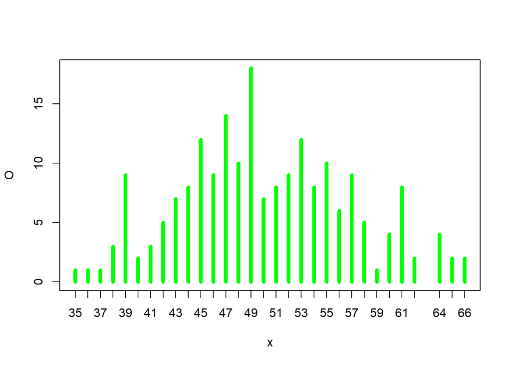

```r
O <- table(x)    ## contingency table / observed frequency
plot(O,type = 'h',col = 'green',lwd = 5 )
```

```r
(n <- length(O )) ## number of categories
```

```
## [1] 31
```

```r
x0 <- as.integer(names(O))    ## unique sample values
```

Получаем вероятности $p_{0,i}$ попадания в каждое $E_i$

```r
p <- dpois(x0, lambda); p <- p / sum(p)
```

и проверяем гипотезу $H_0:x\~ Po(\lambda)$

```r
chq <- chisq.test(O, p = p)
chq$p.value
```

```
## [1] 0.2035416
```

```r
dof <- chq$parameter #degree of freedom
```

гипотеза не отвергается. На самом деле мы сделали не совсем корректно. Так как проверяли сложную гипотезу, а параметр $\lambda$ оценивали по выборке через вычисление среднего выборки. Чуть позднее мы вернемся к этому примеру и исправим

#### Cложная гипотеза

Пусть $F=[F(x,\theta),\theta\in\Theta]$.

В этом случае

$$p_{j}^0 (\theta ) =P(\xi\in
E_{j}|H_0)=\int_{E_{j}}dF(x,\theta),\mspace{25mu} j=1,...,N$$
уже будет функция от параметра $\theta$. Рассмотрим статистику

$$\chi_{n}^{2
}(\theta)=\Sigma_{j=1}^{N}(\nu_{j}-np_{j}^0(\theta))^2/(np_{j}^0(\theta))$$
которая также будет функцией от $\theta\in \Theta$. Однако, справедлива следующая теорема.

**Теорема 2.1** Пусть выполнены следующие условия

a). $\Sigma_{j=1}^{N}p_{j}^0(\theta)=1$ для любого $\theta=(\theta_1,...,\theta_{r})\in \Theta$

b). $p_{j}^0(\theta)≥c>0$

c). Существуют $\frac{dp_{j}^0(\theta)}{d\theta_{k}}$ и
$$\frac{d^2p_{j}^0(\theta)}{d\theta_{k}d\theta_{l}}\mspace{25mu} k,l=1,...,r$$

d). Матрица
$$[\frac{dp_{j}^0(\theta)}{(d\theta_{k})},\mspace{25mu}j=1,..,N;k=1,...r]$$
имеет ранг r.

e). Пусть $\theta=\theta_{n}$ мультиномиальная оценка максимального правдоподобия для любого параметра $\theta\in\Theta$, тогда
$$P(\chi_{n}^{2 }|H_0)->\chi^{2
}(N-r-1)$$
. при $n->\infty$.

Мультиномиальное распределение это

$$P(\nu_1=n_1,....\nu_{N}=n_{N})=\frac
{n!}{n_1!...n_{N}!}p_1^{n_1}(\theta)...p_{N}^{n_{N}}(\theta)$$

и оценки параметров производится решением системы линейных алгебраических уравнений вида

$$\Sigma_{i=1}^{N}\frac{n_{i}}{p_{i}(\theta)}\frac{dp_{i}(\theta)}{(d\theta_{k}}=0\mspace{25mu} k=1,...,r$$

Чернов и Леман в 1954 году показали, что при **другом методе оценивания предельное соотношение, вообоще говоря не имеет места!!!**.

#### Cложная гипотеза для проверки нормальности

Коллекция методов для проверки сложной гипотезы нормальности находится в библиотеке library(nortest). Там мы найдем метод критерия $\chi$-квадрат для прверки сложной гипотезы о нормальности это метод pearson.test()

```r
library(nortest)
pearson.test(sam1)
```

```
##
##  Pearson chi-square normality test
##
## data:  sam1
## P = 19.2, p-value = 0.3172
```

#### Сложная гипотеза дискретная выборка

Для проверки как простых так и сложных гипотез о распределении дискретных данных предлагается использовать библиотеку library(vcd), метод goodfit()  
Посмотрим как это работает на смоделированной выборке с биномиальным распределением.

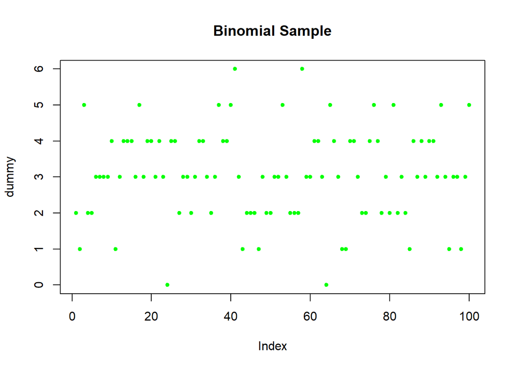

```r
dummy <- rbinom(100, size = 6, prob = 0.5)
plot(dummy,type = 'p',pch = 20,col = "green",main = "Binomial Sample")
```

Сначала проверим простую гипотезу, и специально зададим неправильно параметр распределения $p=0.6$, а не $p=0.5$ как это было при моделировании.

```r
library(vcd)
gf2 <- goodfit(dummy, type = "binomial", par = list(prob = 0.6, size = 6))
summary(gf2)
```

```
##
##   Goodness-of-fit test for binomial distribution
##
##                       X^2 df     P(> X^2)
## Pearson          24.79571  6 0.0003725056
## Likelihood Ratio 20.54888  6 0.0022101924
```

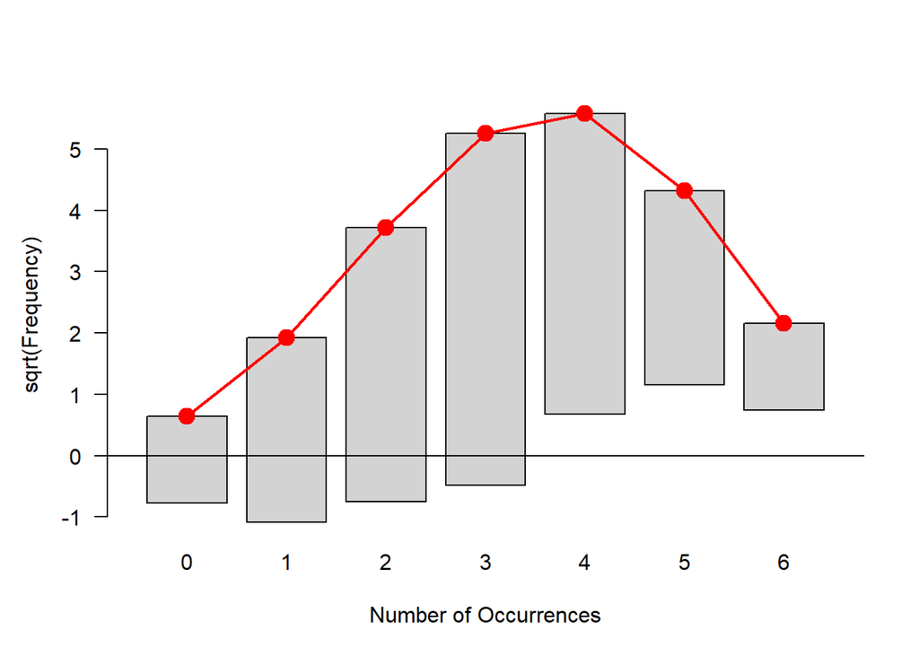

```r
plot(gf2)
```

Посмотрим на p-value и гипотеза естественно отвергается`

Теперь посмотрим сложную гипотезу

```r
gf1 <- goodfit(dummy, type = "binomial", par = list(size = 6))
summary(gf1)
```

```
##
##   Goodness-of-fit test for binomial distribution
##
##                        X^2 df  P(> X^2)
## Likelihood Ratio 0.6812514  5 0.9839818
```

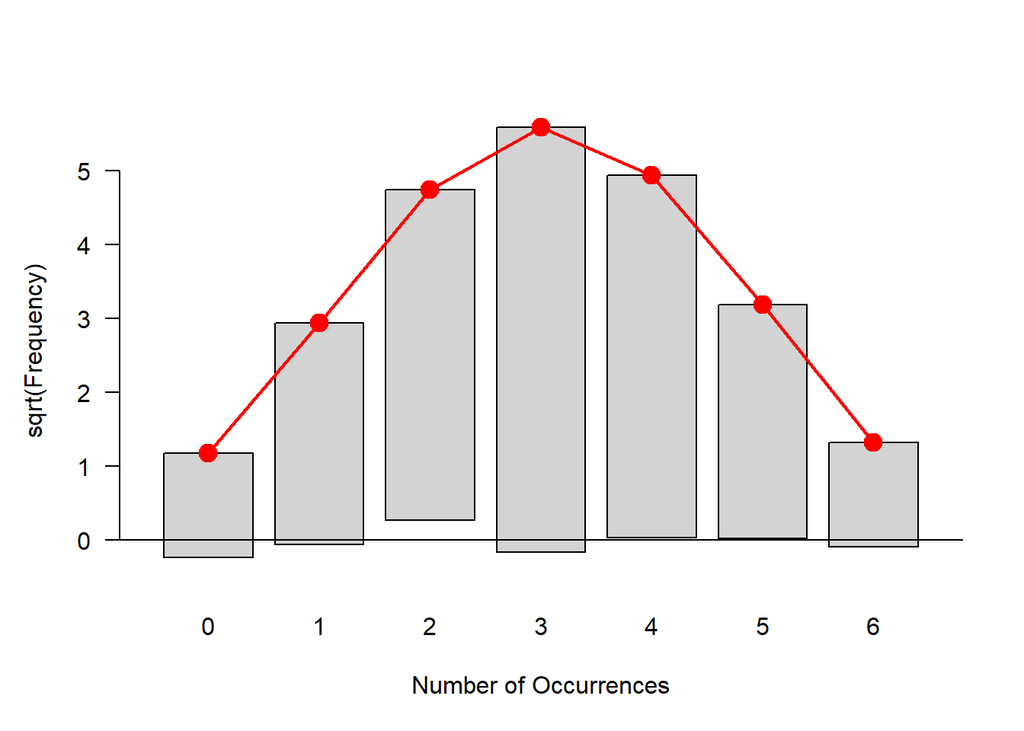

```r
plot(gf1)
```

Гипотеза о биномиальном распределении выборки не отвергается.

Попробуем теперь проверить сложную гипотезу о распределении Пуассона нашей биномиальной выборки

```r
gf3 <- goodfit(dummy, type = "poisson" )
summary(gf3)
```

```
##
##   Goodness-of-fit test for poisson distribution
##
##                       X^2 df     P(> X^2)
## Likelihood Ratio 21.38377  5 0.0006853695
```

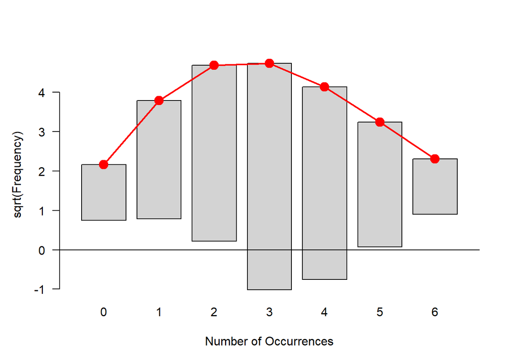

```r
plot(gf3)
```

Гипотезу естественно должна быть отвергнута.

Возвращаемся к примеру с Пуассовской выборкой. Теперь проверим сложную гипотезу с помощью метода goodfit

```r
gf4 <- goodfit(x, type = "poisson" )
summary(gf4)
```

```
##
##   Goodness-of-fit test for poisson distribution
##
##                       X^2 df  P(> X^2)
## Likelihood Ratio 47.03591 29 0.0184613
```

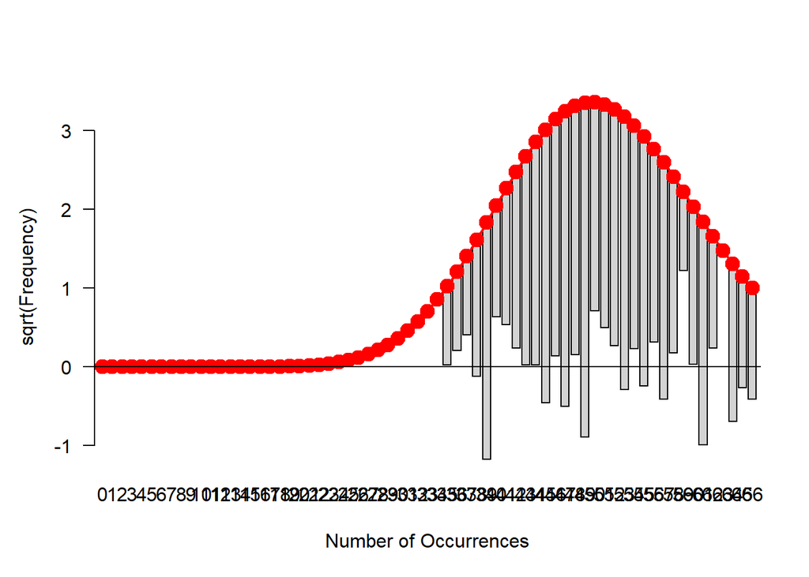

```r
plot(gf4)
```

```r
gf4$par
```

```
## $lambda
## [1] 50.125
```

```r
gf4$df
```

```
## [1] 29
```

Обратите внимание на число степеней свободы в начале этого примера и сейчас. Ceйчас на 1 меньше, так как оценивался один параметр  
$\lambda$.При сложной гипотезе число степеней свободы должно быть $N-k-1$, где $k$ число параметров. Но $\lambda$ похоже оценивали по исходной выборке, что, вообще говоря, неверно.

Действительно оценка параметра из метода goodfit() и среднее по выборке совпадает.

```r
gf4$par
```

```
## $lambda
## [1] 50.125
```

```r
mean(x)
```

```
## [1] 50.125
```

Я попробовал оценить параметр $\lambda$, как требует наука, через минимизацию статистики $\chi$-квадрат и получил совсем другую оценку для $\lambda$.

```r
O <- table(x)    ## contingency table / observed frequency
(n <- length(O )) ## number of categories
```

```
## [1] 31
```

```r
N <- 300
x0 <- as.integer(names(O))    ## unique sample values

chistat <- function(lambda)
{
  p <- dpois(x0, lambda)
  p <- p / sum(p)

  chisq <- sum((x0-p*N)^2/(p*N))
  return(chisq)
}
par <- 10
res <- optim(par,chistat,NULL,method = "CG")
(trueLambda <- res$par)
```

```
## [1] 51.92512
```

Проверка гипотезы с этим $\lambda$ дает.

```r
p <- dpois(x0, trueLambda); p <- p / sum(p)
chq <- chisq.test(O, p = p)
chq$p.value
```

```
## [1] 0.02769683
```

Интересно, что наши `западные партнеры` эту специфику проверки сложных гипотез, мягко говоря, игнорируют. Сравните статью в русско-язычной википедии и аналогичную английскую версию https://en.wikipedia.org/wiki/Pearson%27s_chi-squared_test. О сложных гипотезах в английской версии нет ни слова. И реализация R, как мы видели соответсвующая - оцениваем параметры по выборке и уменьшаем число степеней свободы, что, вообще говоря, не правильный подход.

## Пример с курсом Рубля

Посмотрим пример с курсом рубля

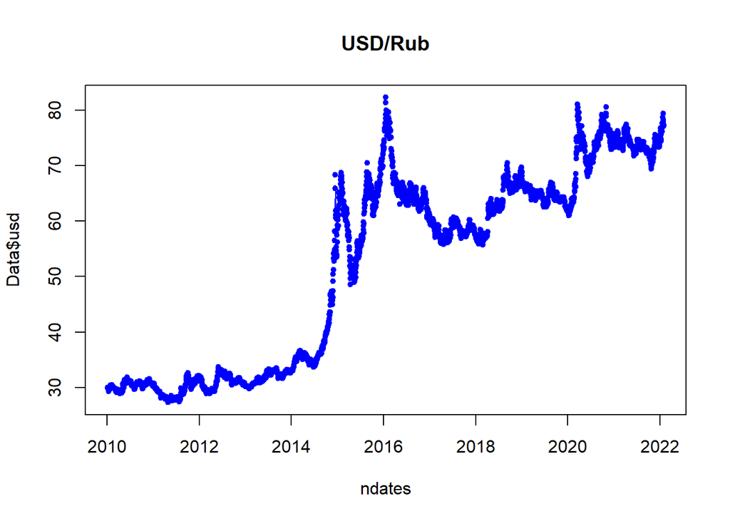

```r
   Data <- read.csv("RubleBrent.csv",sep=",")
   ndates <- as.Date(Data$date, "%m/%d/%y")
   matplot(ndates, Data$usd,type="b",pch =20,col = 'blue',main = "USD/Rub")
```

Переходим к доходностям
$$r_t=R_t/R_{t-1}-1$$

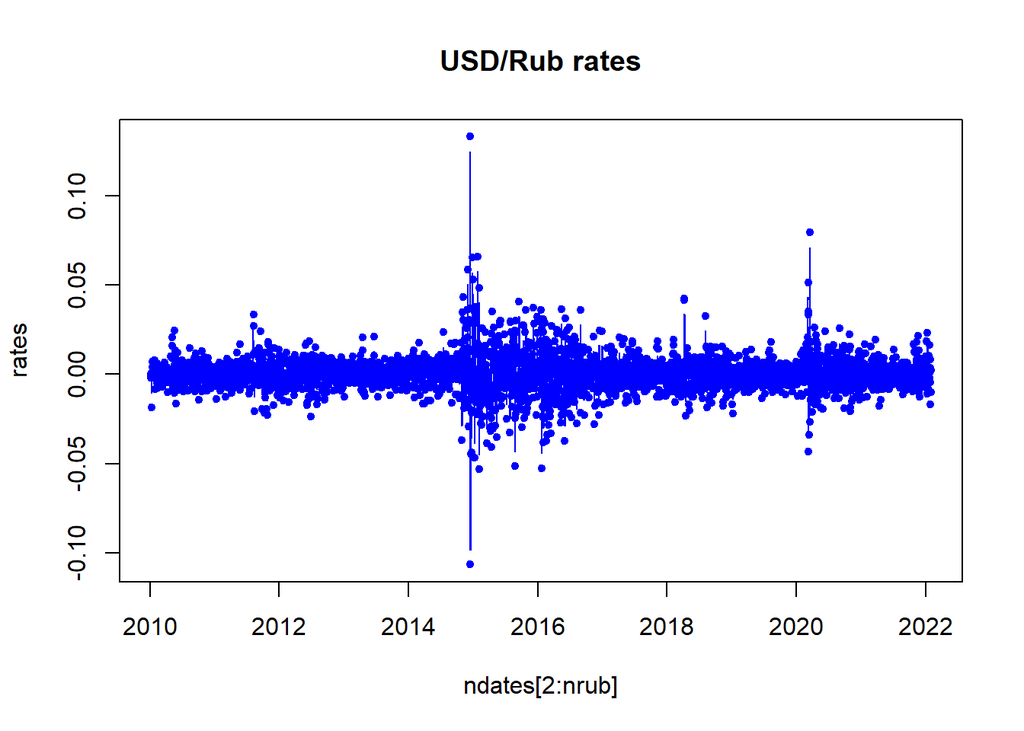

```r
nrub <- length(Data$usd)
rates <- Data$usd[2:nrub]/Data$usd[1:(nrub-1)]-1
matplot(ndates[2:nrub], rates,type="b",pch =20,col = 'blue',main = "USD/Rub rates")
```

Гистограмма

```r
library(fBasics)
```

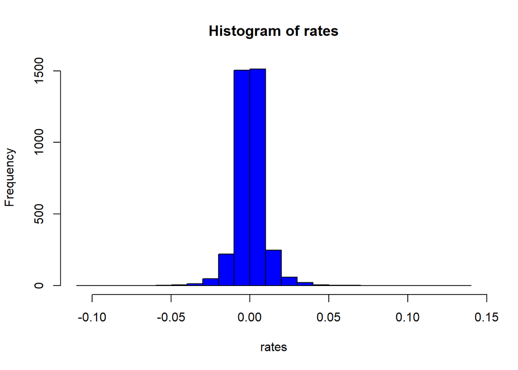

```r
h <- hist(rates,col = "blue",nclass=20)
```

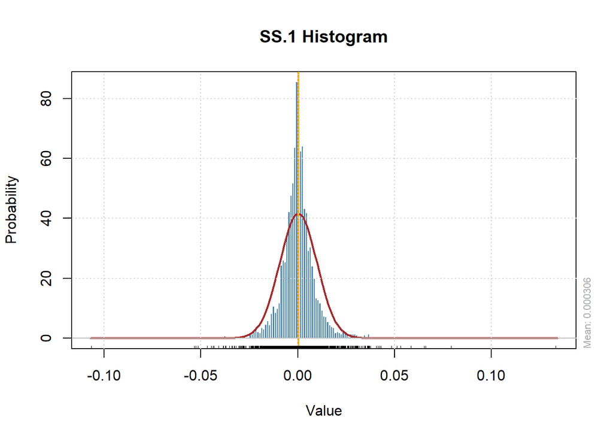

```r
histPlot(as.timeSeries(rates))
```

Проверим независимость и одинаковую распределенность

```r
library(randtests)
rank.test(rates)
```

```
##
##  Mann-Kendall Rank Test
##
## data:  rates
## statistic = -0.40765, n = 3648, p-value = 0.6835
## alternative hypothesis: trend
```

```r
bartels.rank.test(rates)
```

```
##
##  Bartels Ratio Test
##
## data:  rates
## statistic = 3.6339, n = 3648, p-value = 0.0002792
## alternative hypothesis: nonrandomness
```

```r
cox.stuart.test(rates)
```

```
##
##  Cox Stuart test
##
## data:  rates
## statistic = 888, n = 1824, p-value = 0.2711
## alternative hypothesis: non randomness
```

```r
runs.test(rates)
```

```
##
##  Runs Test
##
## data:  rates
## statistic = 3.941, runs = 1944, n1 = 1824, n2 = 1824, n = 3648, p-value
## = 8.113e-05
## alternative hypothesis: nonrandomness
```

```r
turning.point.test(rates)
```

```
##
##  Turning Point Test
##
## data:  rates
## statistic = 1.8984, n = 3648, p-value = 0.05764
## alternative hypothesis: non randomness
```

Мнение тестов разделилось. Дело в основном а неодинаковой распределенности. Дииперсия не одинакова.Попробуем взять последний год

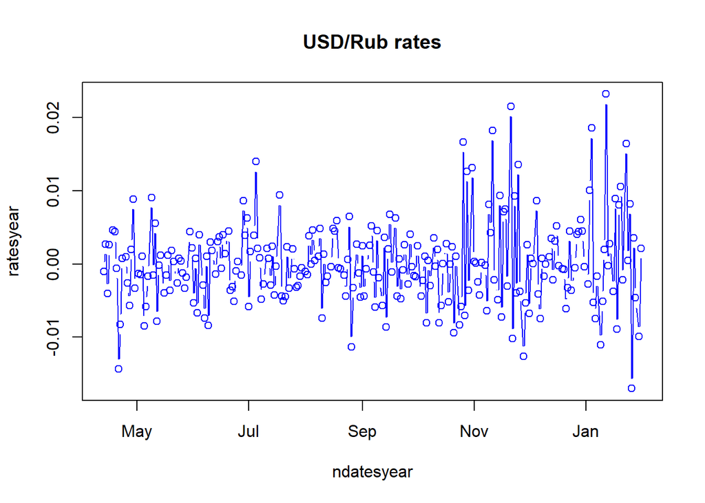

```r
ratesyear <- rates[(nrub-252):(nrub-1)]
ndatesyear <- ndates[(nrub-252):(nrub-1)]
matplot(ndatesyear, ratesyear,type="b",pch =21,col = 'blue',main = "USD/Rub rates")
```

Проверим независимость и одинаковую распределенность

```r
library(randtests)
rank.test(ratesyear)
```

```
##
##  Mann-Kendall Rank Test
##
## data:  ratesyear
## statistic = 0.6565, n = 252, p-value = 0.5115
## alternative hypothesis: trend
```

```r
bartels.rank.test(ratesyear)
```

```
##
##  Bartels Ratio Test
##
## data:  ratesyear
## statistic = 2.3332, n = 252, p-value = 0.01964
## alternative hypothesis: nonrandomness
```

```r
cox.stuart.test(ratesyear)
```

```
##
##  Cox Stuart test
##
## data:  ratesyear
## statistic = 61, n = 126, p-value = 0.7894
## alternative hypothesis: non randomness
```

```r
runs.test(ratesyear)
```

```
##
##  Runs Test
##
## data:  ratesyear
## statistic = 2.1461, runs = 144, n1 = 126, n2 = 126, n = 252, p-value =
## 0.03187
## alternative hypothesis: nonrandomness
```

```r
turning.point.test(ratesyear)
```

```
##
##  Turning Point Test
##
## data:  ratesyear
## statistic = 0.19993, n = 252, p-value = 0.8415
## alternative hypothesis: non randomness
```

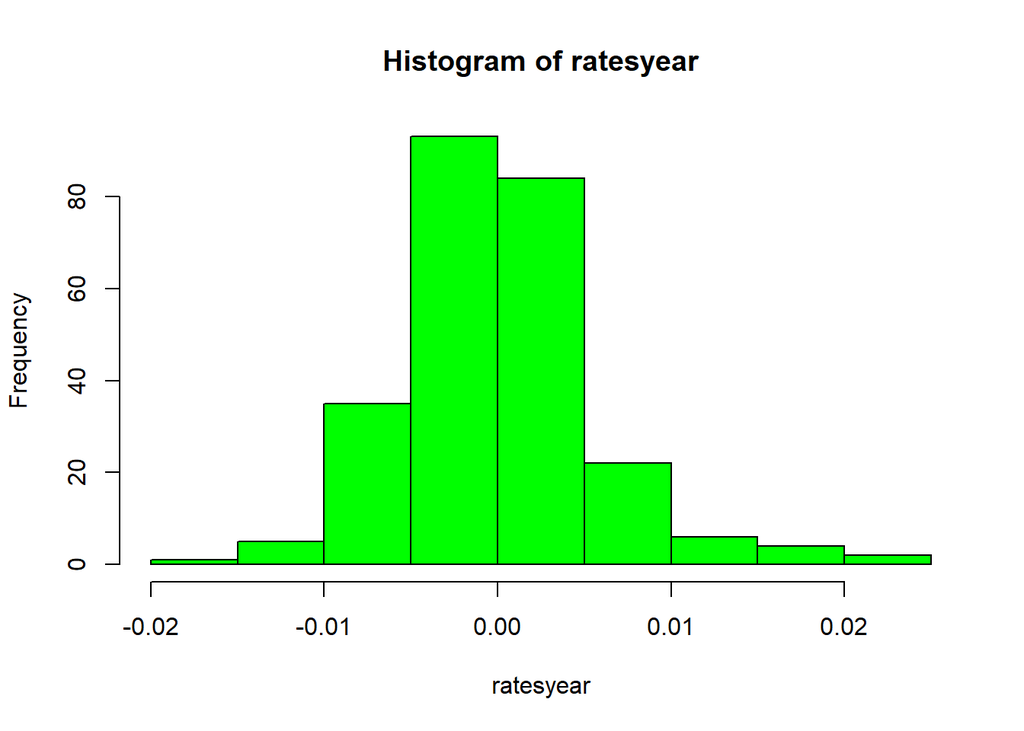

```r
hist(ratesyear,col='green')
```

Чтобы как то отправдать работу с простыми гипотезами поделим случайным образом выборку на тренировочную и тестовую. И оценим параметры подходящих распределений: нормального,t - паспределение Стьюдента по тренировочной выборке

```r
d = sort(sample(length(ratesyear), length(ratesyear)*0.5))
train<-ratesyear[d]
test<-ratesyear[-d]
length(test)
```

```
## [1] 126
```

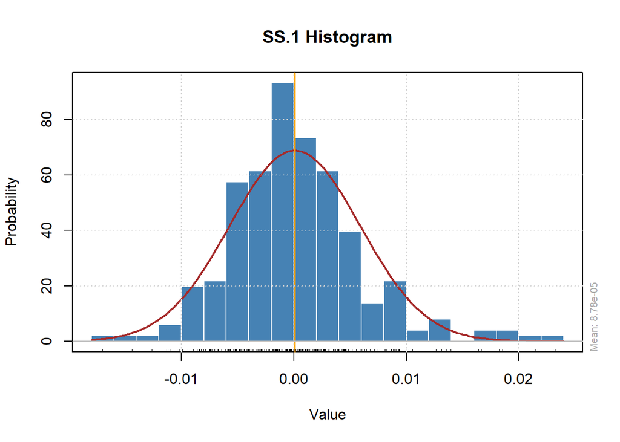

```r
library(MASS)
histPlot(as.timeSeries(ratesyear))
```

```r
(fitting_normal<-fitdistr(train,"normal"))
```

```
##        mean             sd
##   -9.061825e-06    5.472568e-03
##  ( 4.875351e-04) ( 3.447394e-04)
```

```r
(fitting_student<-fitdistr(abs(train),"t"))
```

```
##         m              s              df
##   0.0031651096   0.0025817073   3.5733680813
##  (0.0002877174) (0.0001697855) (1.0557660803)
```

Теперь Будем проверять гипотезы согласия Колмогорова-Смрнова. Для критерия согласия с распределением Стьюдента будем использовать специально заточенный метод библиотеки LambertW.

```r
library(LambertW)
```

```r
 library(ggplot2)
ks.test(test,'pnorm',fitting_normal$estimate[1],fitting_normal$estimate[2])
```

```
##
##  One-sample Kolmogorov-Smirnov test
##
## data:  test
## D = 0.062831, p-value = 0.7024
## alternative hypothesis: two-sided
```

```r
tparam <- c(location = fitting_student$estimate[1], scale = fitting_student$estimate[2], df = fitting_student$estimate[3])
ks_test_t(ratesyear,param=NULL)
```

```
##
##  One-sample Kolmogorov-Smirnov test student-t with df=4.98, location=0,
##  scale=0
##
## data:  ratesyear
## D = 0.030943, p-value = 0.9693
## alternative hypothesis: two-sided
```

### Непрерывные распределения

Для предварительного выбора наиболее подходящего для данной выборки распределения полезна library(rriskDistributions) и метод fit.cont(). Он создает GUI (ГИП - Графический Интерфейс Пользователя) при помощи которого исследователь самостоятельно выберет наиболее подходящее распределение выборки.

```r
#library(rriskDistributions)
#fit.cont(data2fit = sam1)
```

```r
#sam2 <- runif(500,min = 2, max = 4)
#fit.cont(data2fit = sam2)
```